# Лабораторная работа №5

Операционные системы - Бекауов А.Т

Российский университет дружбы народов, Москва, Россия

# Введение

## Цель работы

Цель данной лабораторной работы - ознакомится с менеджером паролей pass и дополнительным программным обеспечением и научится работать с менеджерами файлов конфигураций

## Задачи

1.Ознакомится с менеджером паролей pass

2.Ознакомится с дополнительным программным обеспечением

3.Научится работать с менеджером файлов конфигураций

# Выполнение лабораторной работы

## Установка пакетов pass, pass-otp

Установил пакеты pass и pass-otp.

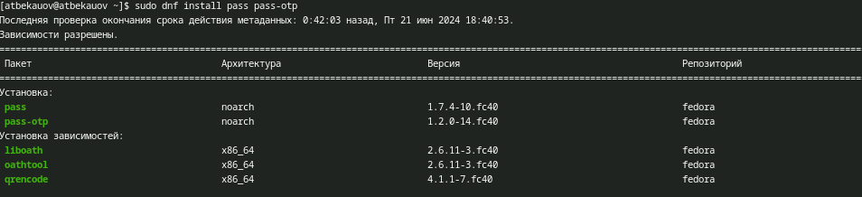

## Установка пакета gopass

Далее устанавливаю пакеты gopass

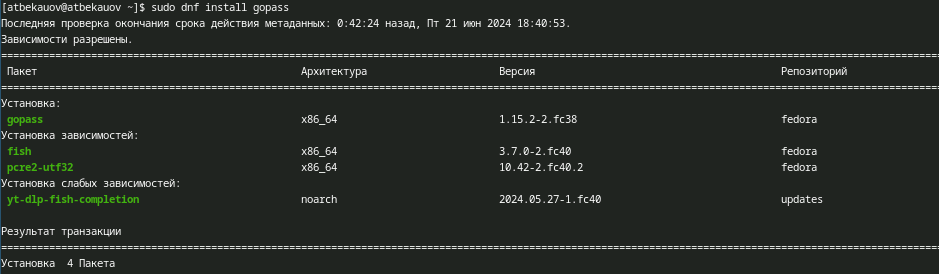

## Инициализация хранилища

Затем просматриваю список ключей GPG (один ключ есть, он использовался в ЛР2) и инициализирую хранилище и создаю структуру git.

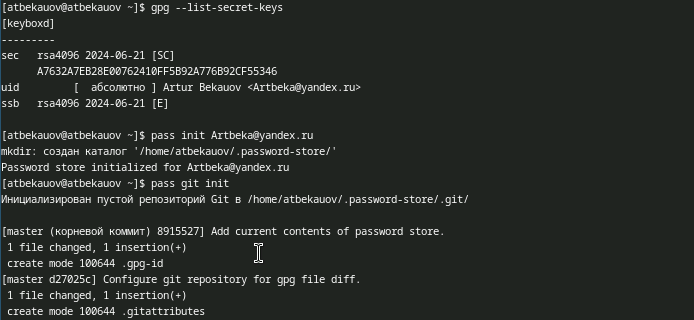

## Репозиторий gitpass

Создаю на GH репозиторий gitpass.

[figure not shown]

## Задание адреса и синхронизация

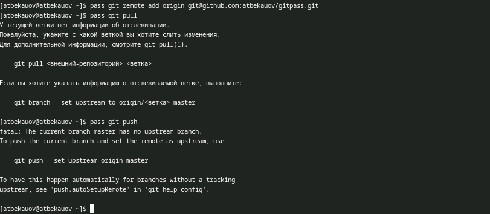

## Ручной коммит

Далее проверяю возможность ручного коммита и проверяю статус синхронизации.

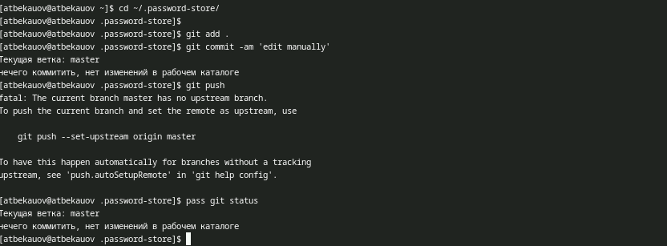

## Установка плагина для браузера

Для работы pass с браузером устанавливаю плагин для Firefox.

[figure not shown]

## Установка пакета browserpass

А для настройки интерфейса взаимодействия с браузером, включаю репозитории Copr и скачиваю пакет browserpass (browserpass-native).

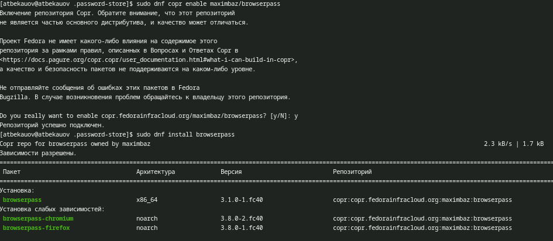

## Создание пароля

Далее добавляю новый пароль и отображаю его же.

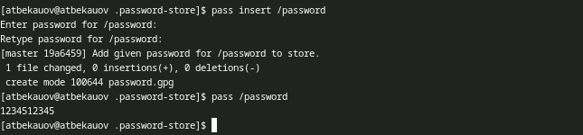

## Генерация и замена пароля

Затем заменяю этот пароль на сгенерированный (новый пароль обозначен жёлтым цветом)

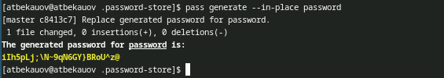

## Установка пакетов доп. ПО

Далее устанавливаю дополнительное ПО.

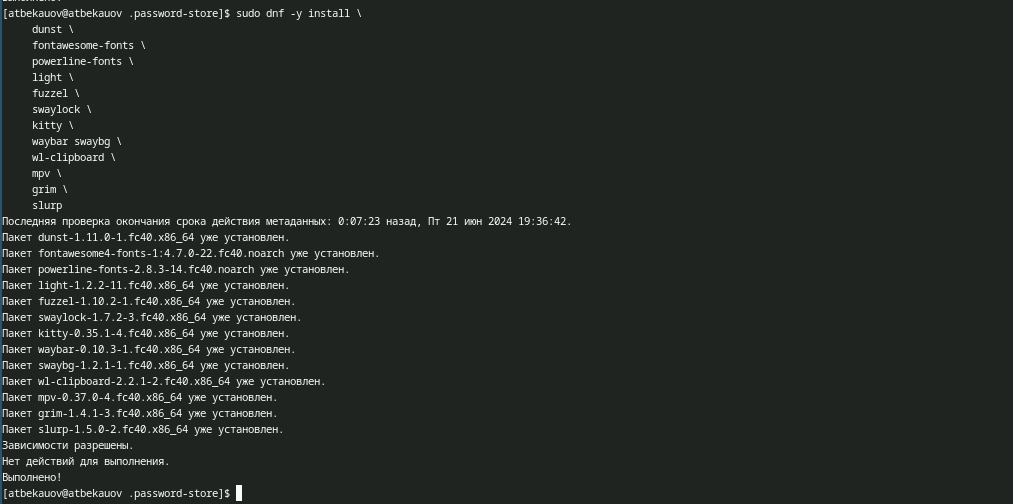

## Установка шрифтов

Также устанавливаю шрифты (подключая репозитории copr).

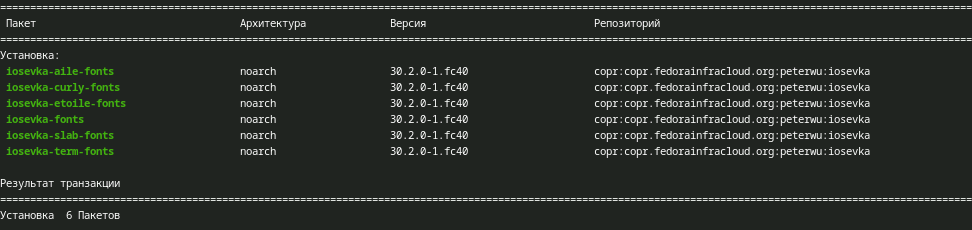

## Установка chezmoi

Затем устанавливаю бинарный файл chezmoi - он помагает управлять файлами конфигурации.

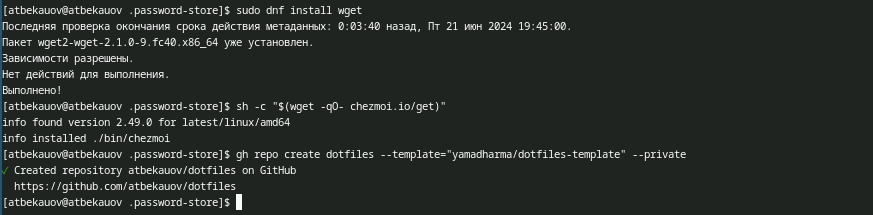

## Создание репозитория для конф. файлов

Далее создаю репозиторий для конфигурационных файлов на основе представленного шаблона

[figure not shown]

## Инициализация chezmoi

Инициализирую chezmoi с созданным репозиторием через ssh.

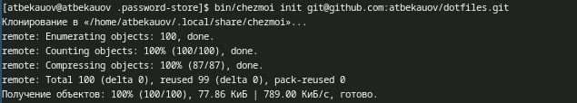

## Взаимодействие chezmoi с репозиторием

Попробуем извлечь последние изменения из репозитория и применить их. Результат - Уже актуально. Далее попробуем установить свои dotfiles на этот компьютер - очевидно ничего не изменилось.

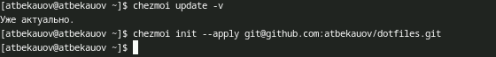

## Автоматизация chezmoi

Настрою автоматическую фиксацию и отправку изменений в репозиторий.

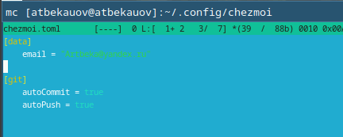

# Заключение

## Выводы

В ходе данной лаботраторной работы я ознакомится с менеджером паролей pass и дополнительным программным обеспечением и научится работать с менеджером файлов конфигураций